# Industry 4.0 의 중심, BigData

Data Processing Based Python @ [FB / jskim.kr](https://www.facebook.com/jskim.kr), 김진수

## 알고리즘, Algorithm

> - 피보나치 함수
> - 자료구조 - 스택(Stack)
> - 자료구조 - 큐(Queue)

```python
# 파이썬 알고리즘 실습
```

### 피보나치 함수

> - N번째 피보나치 함수를 구하는 함수
> - 피보나치(N)은 바로 전번(N-1)값과 전전번(N-2)값의 더한값

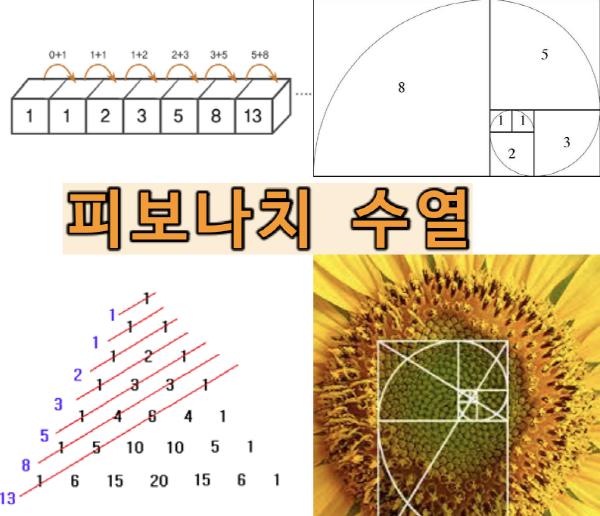

```python
_Figure_("피보나치")
```

```python
def fibonacci(num):
    # fibonacci 기능 구현
    pass

    return ret_num
```

```python
for num in range(25):

    print("Fibonacci({}) = {}".format(num, fibonacci(num)))
```

[output not shown]

### 자료구조 - 스택(Stack)

> 파이썬으로 구현한 스택 자료구조
> - 스택은 push와 pop이라는 기능을 가지고 있습니다.
> - 스택 자료구조는 말 그대로, 쌓아 올리는 것과 같은 자료구조입니다.
> - 즉, push은 item을 쌓아올리는 기능이고, pop은 쌓여져 있는 item에서 제일 위의 것을 꺼내는 작업입니다.
> - 따라서 스택 자료구조는 Last In First Out(LIFO) 와 같은 특성을 가지고 있습니다.

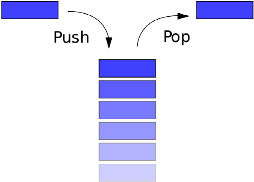

```python
_Figure_("스택")
```

##### 스택 구현

- 클래스로 스택(Stack)객체를 만들고,
- push와 pop기능을 구현하고
- 해당 스택이 비어있는지 확인하는 isEmpty기능까지 구현합니다.
- 또한 스택이 비어있을때 pop기능을 시도하면 에러메세지를 출력하며 False 값을 리턴하게 하겠습니다.

```python
class Stack:
    def __init__(self):
        self.stack_items=[]

    def pop(self):
        # pop 기능 구현
        pass

    def push(self,x):
        # push 기능 구현
        pass

    def isEmpty(self):
        # isEmpty 기능 구현
        pass
```

```python
# 테스트 코드
ds_stack = Stack()
print(ds_stack.stack_items)
ds_stack.push(3)
print(ds_stack.stack_items)
ds_stack.push(5)
print(ds_stack.stack_items)
ds_stack.push(7)
ds_stack.push(9)
ds_stack.push(11)
print(ds_stack.stack_items)
print(ds_stack.isEmpty())
print(ds_stack.pop())
print(ds_stack.pop())
print(ds_stack.pop())
print(ds_stack.pop())
print(ds_stack.pop())
print(ds_stack.pop())
print(ds_stack.isEmpty())
```

[output not shown]

### 자료구조 - 큐(Queue)

> 파이썬으로 구현한 큐 자료구조
> - 큐 자료구조는 요소(item)을 삽입하는 Enqueue 기능과 요소를 빼내는 Dequeue 기능이 있습니다.
> - 처음에 삽입한 요소가 먼저 빠지게 되는 First In First Out(FIFO) 특징을 가지고 있습니다.

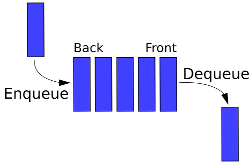

```python
_Figure_("큐")
```

##### 큐 구현

```python
class Queue:
    def __init__(self):
        self.queue_items = []

    def enqueue(self, x):
        # enqueue 기능 구현
        pass

    def dequeue(self):
        # dequeue 기능 구현
        pass

    def isEmpty(self):
        # isEmpty 기능 구현
        pass
```

```python
ds_queue = Queue()
print(ds_queue.queue_items)
ds_queue.enqueue(1)
print(ds_queue.queue_items)
print(ds_queue.dequeue())
print(ds_queue.queue_items)
ds_queue.enqueue(2)
ds_queue.enqueue(3)
ds_queue.enqueue(4)
ds_queue.enqueue(5)
print(ds_queue.queue_items)
print(ds_queue.dequeue())
print(ds_queue.dequeue())
print(ds_queue.queue_items)
print(ds_queue.dequeue())
print(ds_queue.dequeue())
print(ds_queue.dequeue())
print(ds_queue.isEmpty())
```

[output not shown]

The BigpyCraft find the information to design valuable society with Technology & Craft.

< The End >